# Árboles de Clasificación y regresión

Introducción al Aprendizaje Estadístico

Kael Huerta, Enrique Bonilla

2016-08-04

### Nota: los paquetes que se utilizaran en estas notas son los siguientes:

```r
require(ggplot2)
require(ggdendro)
require(plyr)
require(dplyr)
require(tidyr)
require(kknn)
require(rpart)
require(tree)
require(mlbench)
require(randomForest)
require(gbm)
require(data.table)
```

# Introducción

## Aprendizaje Estadístico

En el mundo del análisis de datos existen 2 formas de concebir el modelado estadístico:

- **Data modeling culture**: su objetivo es el diagnóstico. Fuerte en teoría y utiliza pocos datos.
- **Algorithmic modeling culture**: su finalidad es predecir futuras observaciones. Aunque no se ha desarrollado mucha teoría matemática, se desempeña muy bien ante grandes cantidades de datos.

Cada uno de estos enfoques es útil en distintas situaciones. En particular, el Aprendizaje Estadístico utiliza el segundo enfoque.

Algunos términos relacionados que son frecuentemente mencionados en la literatura son los siguientes:

- **Aprendizaje de Máquina**: análisis de algoritmos.
- **Minería de Datos**: bases de datos grandes.
- **Aprendizaje estadístico**: teoría estadística detrás de las últimas dos.

El aprendizaje estadístico se divide en dos principales ramas:

- **Aprendizaje Supervisado**: predecir la variable dada $Y$ (conocemos la respuesta). Si la variable de respuesta es cuantitativa se conoce como problema de *regresión*. Si es cualitativa, se denomina problema de *clasificación*.
- **Aprendizaje No Supervisado**: no hay variable respuesta. Se trata de encontrar estructuras intrínsecas en los datos.

Aprendizaje supervisado. Problema de regresión.

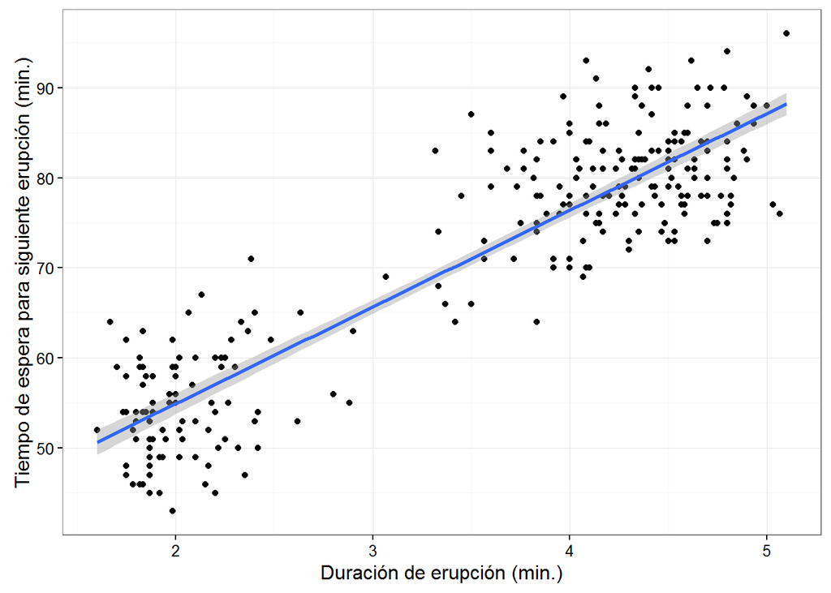

```r
## Método: regresión lineal
## Datos: old faithful géiser en Yellowstone National Park, Wyoming, USA
## Librerias: base

faithful %>%
  ggplot(aes(x = eruptions, y = waiting)) +
    geom_point() +
    geom_smooth(method='lm') +
    xlab("Duración de erupción (min.)") +
    ylab("Tiempo de espera para siguiente erupción (min.)")
```

Aprendizaje supervisado. Problema de clasificación.

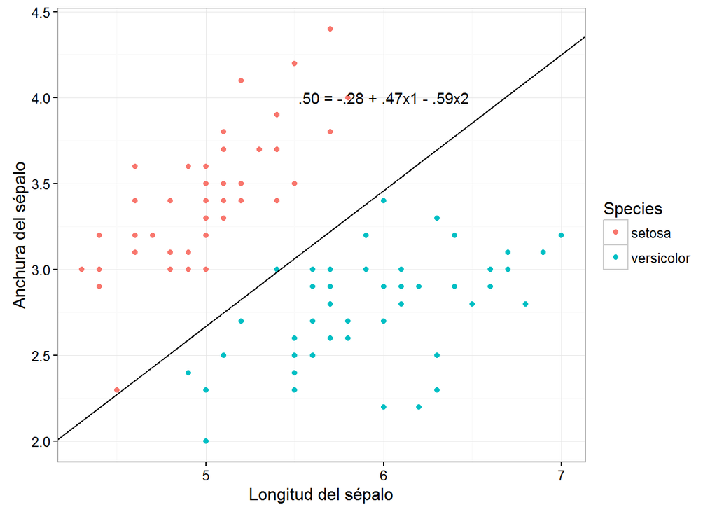

```r
## Método: regresión lineal
## Datos: flores de Fisher
## Librerias: base

datos <- iris %>%
  filter(Species %in% c("setosa", "versicolor") ) %>%
  mutate(specie = as.numeric(ifelse(Species== "setosa", 0, 1)))

modelo <- datos %>%
  lm(formula = "specie ~ Sepal.Length + Sepal.Width")

## Si y > .5 entonces se clasifica 1

datos %>%
  ggplot(aes(x = Sepal.Length, y = Sepal.Width, colour = Species)) +
    geom_point() +
    geom_abline(intercept = -1.28, slope = .79)  +
    annotate("text", x = 6, y = 4, label = ".50 = -.28 + .47x1 - .59x2") +
    xlab("Longitud del sépalo") +
    ylab("Anchura del sépalo")
```

Aprendizaje no supervisado. Problema de agrupamiento.

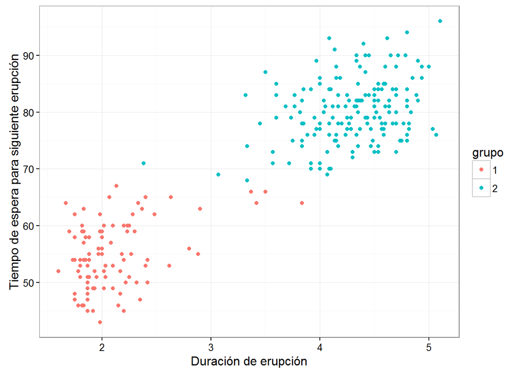

```r
## Método: k-medias
## Datos: old faithful géiser en Yellowstone National Park, Wyoming, USA
## Librerias: base

modelo <- kmeans(faithful, 2)

datos <- data.frame(faithful, grupo = as.character(modelo$cluster))

datos %>%
  ggplot(aes(x = eruptions, y = waiting, color = grupo)) +
  geom_point() +
  xlab("Duración de erupción") +
  ylab("Tiempo de espera para siguiente erupción")
```

Los *métodos basados en árboles* (CART, Bosques Aleatorios, etc.) son algoritmos de aprendizaje supervisado. Estos pueden tener como respuesta una variable numérica ($Y$) o una variable categórica ($G$).

## Supuestos y notación

Se define a $X = (X_1, \ldots, X_p)$ como la variable de entrada y a $Y$ como la variable de respuesta cuantitativa, $G$ en caso de ser cualitativa. Se asume que $X$ y $Y$ están relacionadas a través de un modelo probabilístico $P(X,Y)$ donde $P(X,Y)$ es su distribución de probabilidad conjunta. Por lo general, $P(X,Y)$ es un objeto complicado que no conocemos y es difícil de estimar.

En el caso de regresión, suponemos que se puede escribir $Y = f(X) + \epsilon$ donde $E[\epsilon] = 0$ y es independiente de X. Para este modelo, $f(x) = E[Y \mid X = x]$. Nuestro objetivo es estimar $f(X)$ por medio de una aproximación $\hat{f}$ usando los datos observados.

La idea es que $f(X)$ captura toda la información sistemática de $X$ acerca de $Y$, así que $\epsilon$ es independiente de $X$.

En algunos problemas, se puede suponer que $Y = f(X)$ o que los errores no son independientes e idénticamente distribuidos.

Típicamente, la $f$ estimada depende de un parámetro o conjunto de parámetros de **ajuste** $\alpha$, i.e, $\hat{f}_{\alpha}$.

Cuando se trata del problema de clasificación, nuestro objetivo es estimar $P(G \mid X)$ y esto se modela directamente.

Para construir la regla de predicción ($\hat{f}$ o $\hat{P}$ dependiendo el caso) usamos datos observados. Al conjunto de datos observados $\Gamma = \{(x_1, y_1), \ldots, (x_n, y_n)\}$ con los que se evalúa el modelo se le conoce como *conjunto de entrenamiento*.

## Teoría de decisión

Al igual que en la estadística bayesiana, el aprendizaje estadístico se apoya de la teoría de decisión para tomar decisiones basado en los principios de la elección coherente. Denotaremos a la *función de pérdida* como $L(Y,\hat{f}(X))$. En teoría, nuestro objetivo será encontrar $\hat{f}(X)$ dentro de una familia de funciones $F$ que minimice  
la *pérdida esperada* sobre observaciones futuras, i.e, $\begin{equation*} \begin{aligned} & \underset{f}{\text{min}} & & E[L(Y_0,\hat{f}(X_0)] \\ & \text{s.a.} & & f\in F \\ & & & X_0,Y_0 \in P(X,Y) \end{aligned} \end{equation*}$

Este problema se puede traducir en encontrar $\alpha$.

El planteamiento común en teoría de decisión es maximizar el valor esperado de una función de utilidad $U(X)$. Se puede ver que estos planteamientos son equivales si $U(X)= -\hat{f}(X)$.

En la práctica, esto se traduce a minimizar el error de predicción de nuestro modelo condicionado a los datos de entrenamiento.

Las funciones de pérdida más comunes en la literatura son las siguientes:

- **Problema de regresión**: $L(Y,\hat{f}(X)) = \begin{cases} (Y - \hat{f}(X))^2 & \quad \text{pérdida cuadrática}\\ \mid X-\hat{f}(X) \mid & \quad \text{pérdida absoluta}\\ \end{cases}$
- **Problema de clasificación**:  
  $L(G,\hat{G}(X)) = G \neq \hat{G} \quad \text{pérdida 0-1}$

$L(G, \hat{P}(G \mid X)) = -2\sum\limits_{k=1}^K I(G = k)log(\hat{P}(G = k \mid X)) \quad \text{log verosimilitud o devianza}$

Como primera opción, uno podría pensar que una estimación del error de predicción se puede obtener por medio del *error de entrenamiento* $\bar{err} = \sum\limits_{i=1}^n L(y_i, \hat{f}(x_i))$ con $(x_i,y_i) \in \Gamma$. Sin embargo, el error de entrenamiento subestima, generalmente, esta cantidad. Esto es porque el error de entrenamiento decrece constantemente al aumentar la **complejidad** del modelo, típicamente llegando a cero, pues si el modelo es muy complejo captura ruido de $\epsilon$.

La manera correcta de estimar el error que vamos a tener al predecir con $\hat{f}(X)$ al ser entrenado con una muestra $\gamma$ es estimando el *error de prueba* también conocido como *error de predición* o *generalization error* $E_{rr\gamma} = E[L(Y,\hat{f}(X)) \mid \gamma]$ donde $\gamma$ es una muestra de $P(X,Y)$.

observemos que $(X,Y)$ son elementos de $P(X,Y)$ no de $\Gamma$ necesariamente.

Como se mencionó anteriormente, estimar $E_{rr\gamma}$ es nuestro principal objetivo pues nos revela no sólo como se comporta la predicción de nuestro modelo $\hat{f}(X)$, si no que, además, sabemos como se va a comportar al ser entrenado con el conjunto de entrenamiento $\Gamma$ que poseemos. Sin embargo, parece que no es posible estimar este error condicional de forma efectiva *sólo con el conjunto de entrenamiento*. Se necesitarían datos independientes a esta muestra para hacerlo.

Lo que se puede hacer es estimar el *error de predicción esperado* o *error de prueba esperado* $E[L(Y,\hat{f}(X))] = E_{rr} = E[E_{rr\gamma}]$ y usarlo para comparar y seleccionar modelos. Este valor es más amable al análisis estadístico además de que puede ser estimado con sólo el uso de la muestra de entrenamiento.

$E_{rr}=E_\gamma[E_{X,Y}[L(Y,\hat{F}(X)) \mid \gamma]]$

El error de predicción esperado puede ser aproximado analíticamente por métodos *in-sample* (AIC, DIC, MDL o SRR) o por métodos de reuso de muestras (validación cruzada, *bootstrap*).

En realidad, algunos de estos métodos estiman $E_y[E_{inn}]$. Para más información ver la sección 7.4 de Friedman, Hastie, and Tibshirani (2001) .

Si tenemos muchos datos, lo mejor que podemos hacer es dividir la muestra observada en 3 conjuntos ajenos:

- **Conjunto de entrenamiento**: se usa para entrenar el modelo (puede sobre-ajustar). Se recomienda, empíricamente $50\%$ de la muestra, dependiendo de su tamaño.
- **Conjunto de prueba**: se usa para seleccionar modelos (aún si estima $E_{rr\gamma}$, se puede sobre-ajustar). Se recomienda, empíricamente, $25\%$ de la muestra.
- **Conjunto de validación**: se utiliza para aproximar $E_{rr\gamma}$ de nuestro modelo final. Se recomienda, empíricamente, $25\%$ de la muestra y sólo debe ser utilizado al final para calcular el error. **No** debe formar parte del proceso de selección de modelos (podría sobre-ajustar y estaría dando una sub-estimación del error de predicción real).

Si tenemos un menor tamaño de muestra, ésta se separa sólo en conjuntos ajenos de entrenamiento ($80\%$) y validación ($20\%$). Con el conjunto de entrenamiento estimamos $E_{rr}$ (por medio de métodos de reuso de muestra o *in-sample*) y comparamos / seleccionamos modelos. Con el conjunto de validación estimamos $E_{rr\gamma}$ del modelo final.

## Descomposición en varianza-sesgo

Si asumimos que estamos en el caso de regresión ($Y = F(X) + \epsilon$, $E[\epsilon]=0$, $Var(\epsilon)= \sigma_\epsilon^2$) y usamos la pérdida cuadrática se puede demostrar que $E_{rr}(x_0) = \sigma_\epsilon^2 + sesgo_\gamma^2(x_0) + Var_\gamma(x_0)$

Por simplicidad, supondremos que sólo nos interesa hacer predicción para $X = x_0$

donde

- $\sigma_\epsilon^2 = Var(Y \mid X=x_0)$ es el error irreducible. No depende del ajuste, es aleatoriedad del fenómeno.
- $sesgo_\gamma^2(x_0) = (E[Y \mid X = x_0] -E_\gamma[\hat{f}_\gamma(x_0)])^2$ es el sesgo del método. Mide en promedio cuanto se desvía $\hat{f}_\gamma(x_o)$ del óptimo $E[y \mid X = x_0]$. Entre menos complejo sea el método aumenta el sesgo y, por lo tanto, aumenta el error.
- $Var_\gamma(x_0) = E_\gamma[(\hat{f}_\gamma(x_0)-E_\gamma[\hat{f}_\gamma(x_0)])^2]$ es la varianza del método. mide qué tanto varían las predicciones entre muestras de entrenamiento. Un método muy complejo es un método inestable en el que las predicciones varían mucho entres muestras de entrenamiento.

Esta descomposición se encuentra, generalmente, independientemente de la función de pérdida y del tipo de problema. Por lo general, $E_{rr\gamma}$ tiene un comportamiento con la misma estructura que $E_{rr}$ pero no igual.

Además, dicha descomposición nos muestra cómo, para minimizar el error de predicción, es conveniente encontrar un equilibrio entre sesgo y varianza: seleccionar un modelo suficientemente complejo para que capture la estructura de los datos pero no tan complejo para capturar ruido.

Varianza-Sesgo: entrenamiento vs prueba.

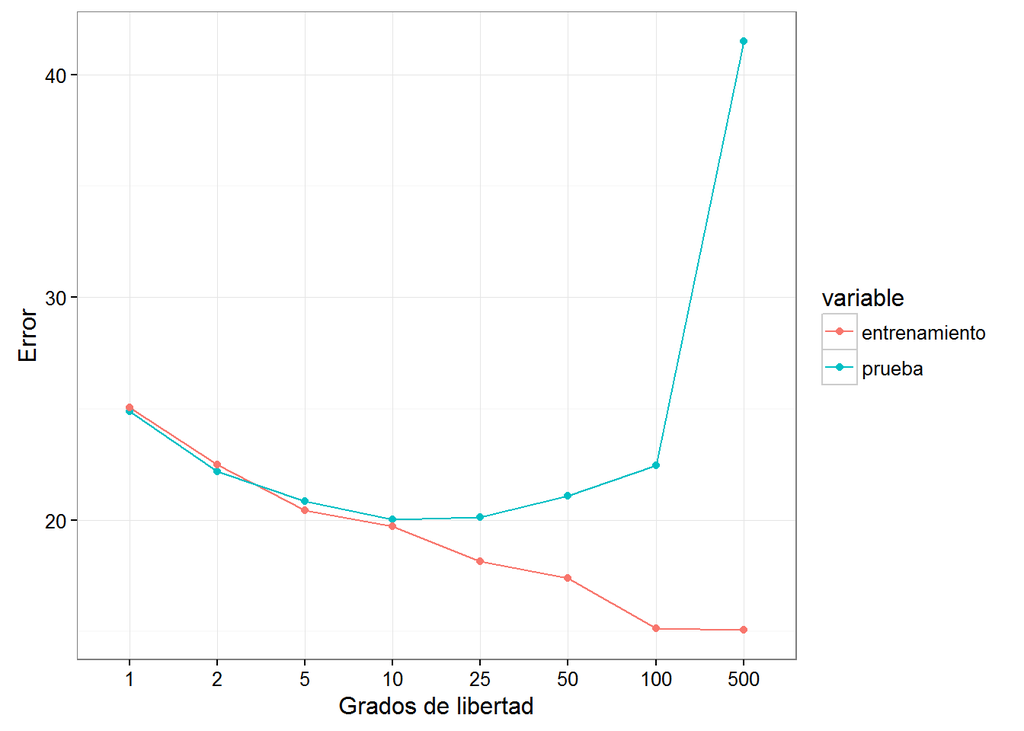

```r
## Método: k vecinos más cercanos
## Datos: Munich Rent Standards
## Librerias: kknn

data(miete)

tamano <- floor(0.65 * nrow(miete))

set.seed(203040)

entrena.ind <- sample(seq_len(nrow(miete)),
                      size = tamano)

entrena <- miete[entrena.ind, ]

prueba <- miete[-entrena.ind, ]


errores.vmc <- ldply(c(1, 5, 10, 20, 50, 100, 250, 500),
                     function(i) {

    vecino.k.prueba <- kknn(nmqm ~ wfl + bjkat + zh,
                            train = entrena,
                            test = prueba,
                            k = i, kernel = "rectangular")

    vecino.k.entrena <- kknn(nmqm ~ wfl + bjkat + zh,
                             train = entrena,
                             test = entrena,
                             k = i, kernel = "rectangular")

    error.prueba <- mean((fitted(vecino.k.prueba) -
                            prueba$nmqm)^2)
    error.entrena <- mean((fitted(vecino.k.entrena) -
                             entrena$nmqm)^2)

    data.frame(k = i, prueba = error.prueba,
               entrenamiento = error.entrena)
})

err.m <- errores.vmc %>%
  gather(variable, valor, -k) %>%
  mutate(n.k = floor(500/k) )

err.m %>%
  ggplot(aes(x = factor(n.k), y = valor,
             colour = variable,
             group = variable)) +
  geom_line() +
  geom_point() +
  xlab("Grados de libertad") +
  ylab("Error")
```

# Árboles de clasificación y regresión

Los modelos basados en árboles son herramientas poderosas para la predicción. Estos van particionando, recursivamente, el espacio de covariables (*feature space*) en rectángulos por medio de modelos simples, como constantes. En esta sección, nos enfocaremos en el método *CART*. Aunque este tipo de árboles, por si solos, son fácilmente superados en la predicción, consituyen la base teórica de técnicas muy poderosas como bosques aleatorios.

Breiman et al. (1984)

Para simplificar, aunque posteriormente veremos que en realidad este enfoque es el más conveniente, CART hace particiones binarias. Primero, se parte el espacio en dos regiones seleccionando la covariable y el corte que ajuste mejor; después, una o ambas de estas regiones se particionan en otras dos de la misma manera y así sucesivamente.

Esta forma de particionar el espacio nos permite representar el modelo gráficamente por medio de un árbol binario, lo que lo hace un modelo fácil de interpretar: los nodos intermedios pueden entenderse como decisiones que dependen de las covaraibles del modelo, los nodos terminales representan la partición final obtenida. En cada uno de los nodos terminales se elige, según algún criterio, un número o clase de predicción. Cómo se puede ver en los árboles binarios, este modelo permite capturar interacciones.

Árbol de clasificación. Representación espacial.

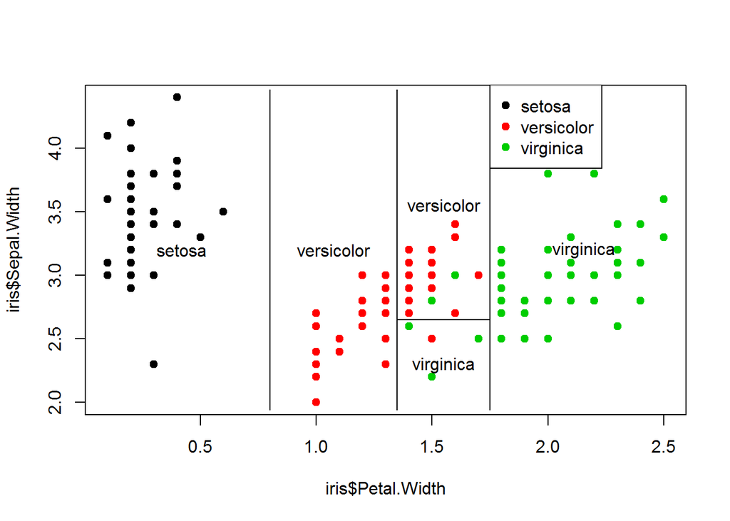

```r
## Método: CART
## Datos: flores de Fisher
## Librerias: tree, rpart, ggdendro

## Modelos
control.completo <- rpart.control(cp=0, minsplit=10,
                                minbucket=1, xval=10, maxdepth=30)

arbol1 <- tree(Species ~ Sepal.Width + Petal.Width, data = iris)
arbol2 <- rpart(Species ~ Sepal.Width + Petal.Width, method = "class",
               data = iris, control = control.completo)

## Particion del feature space
plot(iris$Petal.Width, iris$Sepal.Width, pch=19,col=as.numeric(iris$Species))
partition.tree(arbol1, label="Species", add = T)
legend(1.75,4.5,legend=unique(iris$Species),col=unique(as.numeric(iris$Species)),pch=19)
```

Árbol de clasificación. Representación en árbol binario.

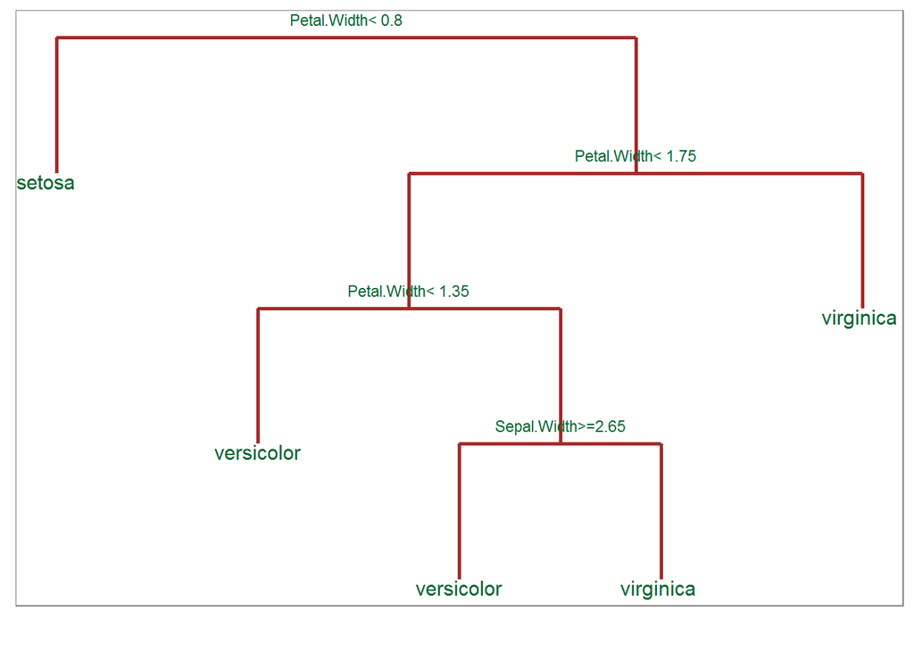

```r
## Dendograma
ddata <- dendro_data(arbol2, uniform =T)

ggplot() +
  geom_segment(data = ddata$segments,
               aes(x = x, y = y, xend = xend, yend = yend), colour = "brown", size = 1) +
  geom_text(data = ddata$labels,
            aes(x = x, y = y, label = label), colour = "#006633", size = 3, vjust = -1) +
  geom_text(data = ddata$leaf_labels,
            aes(x = x, y = y, label = label), colour = "#006633", size = 4, vjust = 1) +
  theme_dendro()
```

Ahora queda por responder las siguientes preguntas: ¿Cómo elegir las particiones? ¿Cómo predecir en los nodos terminales? ¿Cómo declarar un nodo terminal?

## Problema de regresión

Para construir nuestro árbol, recursivamente iremos dividiendo cada nodo que se vaya generando con ayuda de las covariables del modelo $(X_1, \ldots, X_p)$. Se escogerá entre particiones tales que

$R_1(j,z) = \{X \mid X_j \leq z\} \quad \text{y} \quad R_2(j,z) = \{X \mid X_j > z\} \quad \text{si $X_j$ es continua}$

$R_1(j,s) = \{X \mid X_j \in s\} \quad \text{y} \quad R_2(j,s) = \{X \mid X_j \in s^c\} \quad \text{si $X_j$ es categórica}$

Ahora bien, uno podría pensar que nuestro objetivo es dividir nuestro espacio de covariables en las regiones $R_1, \ldots, R_M$ tal que minimicen óptimamente $\sum\limits_{i=1}^N (y_i - \sum\limits_{m=1}^M c_mI(x_i\in R_m))^2$ con $c_m = promedio(y_i \mid x_i \in R_m)$. Sin embargo, este problema no es computacionalmente factible. Lo que haremos es usar un algoritmo codicioso para generar nuestro árbol, en otras palabras, las particiones se escogerán de manera miope o local intentado separar las clases de un nodo lo mejor que se pueda.

nodos terminales

Lo que se hace es, para cada nodo que vaya generando nuestro árbol, encontrar la variable $j$ y el valor $z$ tal que

Para simplificar la notación, supondremos que todas nuestras covariables son continuas.

$\underset{j,z}{\text{min}} \sum_{x_i \in R_1(j,z)}(y_i-c_1)^2 + \sum_{x_i \in R_2(j,z)}(y_i-c_2)^2$

Este proceso se repite hasta construir el árbol más grande que podamos tener. Después nos encargaremos de *podarlo* para tener un mejor árbol predictor.

Mediante este algoritmo, no obtenemos la respuesta óptima pues necesitaríamos “equivocarnos” para encontrarla.

Se define la *impureza* de un nodo $t$ de un árbol $T$, para el problema de regresión, como $i(t) = \frac{1}{N_t}\sum_{x_i \in R_t}(y_i-c_t)^2$ y la *impureza del árbol* como $i(T) = \sum_{t \in T}q(t)i(t)$ con $q(t) = N_t$. Se puede ver que nuestro algoritmo miope se puede traducir a $\underset{t -> t_1\cup t_2}{\text{min}} N_{t_1}i(t_1) + N_{t_2}i(t_2)$ para todos los nodos que se vayan generando con la finalidad de disminuir la impureza del árbol lo más que se pueda.

Una vez construido el árbol, para un valor $x_i$, $x_i \in R_m$ se predice el valor $c_m$.

## Problema de clasificación

Para el problema de clasificación, se pueden utilizar varias medidas de impureza. Estás usan las proporciones de casos en un nodo $t$ que caen en cada categoría $(p_1(t), \ldots, p_K(t))$ para dar una cuantificación de su impureza.

Las más populares son las siguientes:

- **Entropía**: mide la revoltura o desorden de las clases, es parecida a la devianza.

  La teoría estipula logaritmo base 2, sin embargo, se puede usar cualquier base.

$i(t) = - \sum\limits_{k=1}^Kp_k(t)log(p_k(t))$

- **Índice de Gini**: mide la “varianza” de las categorías, es suma de varianzas bernoulli (multinomial).

$i(t) = \sum\limits_{k=1}^Kp_k(t)(1-p_k(t)) = 1 -\sum\limits_{k=1}^Kp_k(t)^2$

- **Error de clasificación**: calcula el porcentaje de casos que mal clasificados con respecto a la categoría más frecuente en el nodo.

$i(t) = 1 - \underset{j}{\text{max}}(p_j(t))$

Cuando $K=2$ estas 3 medidas se comportan similarmente. Sin embargo, cuando $K > 2$ se recomienda usar, para crecer el árbol, Gini o Entropía debido a que contemplan lo que pasa a lo largo de todas las clases, no sólo la clase dominante.

Por ejemplo si tenemos los nodos $(500,200,200)$ y $(500,50,350)$ el error de clasificación es el mismo pero el segundo nodo es mejor porque separa mejor las clases.

Comparación de medidas de impureza. K = 2.

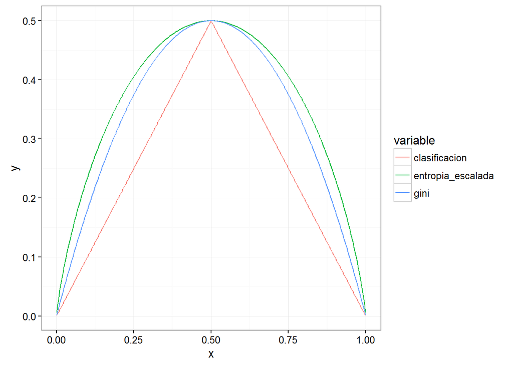

```r
gini <- function(p){
  f <- 1-p^2 -(1-p)^2
  return(f)
}

entropia <- function(p){
  f <- -p*log2(p) - (1-p)*log2(1-p)
  f <- f/2
  return(f)
  }

clasificacion <- function(p){
  f <- 1-pmax(p,(1-p))
  return(f)
}

datos <- data.frame(x = seq(0.001, .999, length =300 )) %>%
  mutate(gini = gini(x), entropia_escalada = entropia(x),
         clasificacion = clasificacion(x)) %>%
  gather(variable, valor, -x)

datos %>% ggplot(aes(x = x, y = valor, group = variable, color = variable)) +
  geom_line() +
  ylab("y")
```

Para el caso de clasificación, la impureza del árbol está dada por

$i(T) = \sum_{t \in T}q(t)i(t)$ con $q(t) = \frac{N_t}{N}$.

y nos interesa resolver en todos los nodos $\underset{t -> t_1\cup t_2}{\text{min}} \frac{N_{t_1}}{N_t}i(t_1) + \frac{N_{t_2}}{N_t}i(t_2)$

Se usa $\frac{N_{t_1}}{N_t}$ y $\frac{N_{t_1}}{N_t}$ para que sea un problema local.

Una vez construido el árbol, para un valor $x_i$, $x_i \in R_m$ se predice con la categoría más frecuente en el nodo.

## Costo-Complejidad

Como se mencionó en la sección anterior, como primer paso para construir nuestro árbol final, el que utilizaremos para predecir, construiremos el árbol más grande posible $T_{max}$. Sin embargo, este árbol va a tener varianza alta debido a que es un modelo muy complejo y está sobre-ajustando, lo que nos llevaría a un mayor error de predicción.

Lo que se puede hacer es pensar en un criterio de paro para el tamaño del árbol. Una primera opción podría ser dividir un nodo sólo si el decrecimiento en la impureza del árbol excede alguna cuota, pero con este criterio podríamos perder buenas separaciones debajo de las separaciones malas.

Una mejor estrategia es podar el árbol (*prunning*) mediante el *costo-complejidad*. Este consiste en sumarle a la impureza del árbol o el error de clasificación (dependiendo el caso) una penalización por el tamaño del árbol $\mid T \mid$ multiplicado por una constante fija $\alpha$, es decir,

$c_\alpha(T) = i(T) + \alpha\mid T \mid$

En un principio uno podría pensar en encontrar un árbol óptimo $T^*(\alpha)$ que minimice $c_\alpha(T)$ para toda $\alpha \geq 0$ y hacer validación cruzada para elegir el mejor parámetro, pero este es un problema demasiado grande.

$\alpha$ más grande penaliza más fuerte el tamaño del árbol y lleva a soluciones con árboles más chicos.

Para resolver este problema, se puede demostrar que para cada $\alpha$ existe un único árbol que minimiza el error de costo-complejidad. Además, vale la pena observar que todas soluciones $T^*(\alpha)$ son sub-árboles del árbol más grande $T_{max}$ y que, a pesar de que existen un número infinito de $\alpha \geq 0$ sólo existe un número finito de sub-árboles.

Breiman et al. (1984) demuestra que existe una sucesión anidada de árboles $T_{max} \leq T_1 \leq T_2 \leq \ldots \leq T_{k+1}$ y una succión correspondiente $\alpha_0 \leq \alpha_1 \leq \ldots \leq \alpha_k$ tal que $T^*(\alpha) = T_j$ si $\alpha_{j-1} \leq \alpha < \alpha_j$, es decir, no necesitamos explorar todas las combinaciones posibles de cortes del árbol más grande para encontrar una solución para una determinada $\alpha$ y, además, no necesitamos encontrar el comportamiento de los árboles para todas las $\alpha \geq 0$, sólo nos basta encontrar el árbol óptimo para un número finito de $\alpha$ y estos árboles son sub-árboles del árbol óptimo generado por $\alpha$ más chica.

Una ves hecho esto encontramos cuál de estos árboles nos da el menor error de predicción o de validación cruzada y ese lo elegimos como el árbol final.

Como nota final, el costo complejidad para problemas de clasificación está dado por $c_\alpha(T) = \bar{err} + \alpha\mid T \mid$ Aunque también se puede usar la impureza del árbol es más común que se use el error de clasificación calculado con la muestra de entrenamiento.

## Ventajas

- Son fáciles de interpretar.
- Capturan interacciones entre las covariables.
- No es necesario transformar variables.
- Son robustos a valores atípicos ya que pueden crear un nodo exclusivo para ese valor y las decisiones de clasificación son muy generales.
- Son robustos ante valores faltantes pues 1) pueden considerar el valor faltante, si la covariable es categórica, con una categoría más y ver que los individuos con valores faltantes se comportan distinto a los que si respondieron y 2) crean cortes sucedáneos buscando variables de entrada que más asemejen el corte encontrado.
- Se ajustan rápidamente.
- Usan cortes binarios para evitar que se acaben los datos en los nodos muy rápido. además de que cortes múltiples pueden ser recreados por una serie de varios cortes binarios.
- Se pueden usar combinaciones lineales para separar un nodo, pero se pierde interpretabilidad.

## Desventajas

- Difícilmente capturan estructuras lineales (regresión lineal).
- En la interpretación, algunas covariables pueden enmascarar a otras. Una variable que no está en el árbol no quiere decir que no sea buena (cortes sucedáneos, qué tan cerca estuvieron de ganar).
- Son muy inestables ($Var_\gamma(T)$ es muy alta). Debido a que son modelos jerárquicos, es muy fácil que con un pequeño cambio en la muestra cambie radicalmente el árbol. Esto produce un desempeño predictor relativamente malo (para este punto, también conviene ver los cortes sucedáneos).
- Cuando tienen como covariable una variable categórica con muchas categorías el árbol sobre-ajusta muy rápido. Esto se debe a lo exhaustivo de la búsqueda (como se construyen los cortes de variables categóricas, ver Breiman et al. (1984) o Friedman, Hastie, and Tibshirani (2001) )

## Ejemplo

Árbol completo

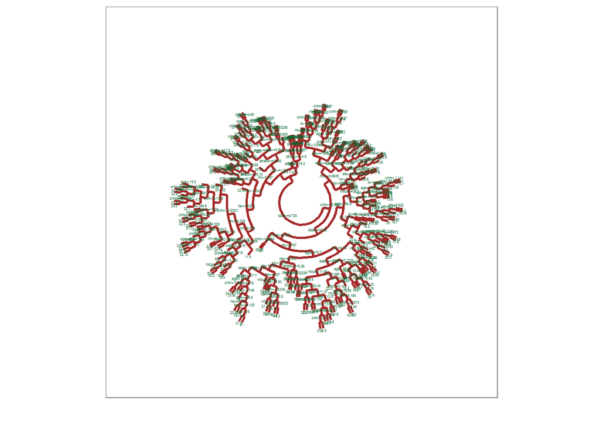

```r
## Método: CART (regresión)
## Datos: Boston Housing (librería mlbench):
## Housing data for 506 census tracts of Boston from the 1970 census
## medv =   median value of owner-occupied homes in USD 1000's
## Librerias: rpart, ggdendro

data(BostonHousing)
set.seed(15)
train <- sample(1:nrow(BostonHousing),400)
BostonHousing$train <- F
BostonHousing$train[train] <- T
entrena.arb <- BostonHousing[BostonHousing$train,]
prueba.arb <- BostonHousing[!BostonHousing$train,]
entrena.arb$train <- NULL

## Modelo completo
modelo.arb.completo <- rpart(medv~., data = entrena.arb, method = "anova",
                       control=rpart.control(cp=0 , xval=10, minbucket=1))

## Dendograma completo
ddata <- dendro_data(modelo.arb.completo , uniform =T)

ggplot() +
  geom_segment(data = ddata$segments,
               aes(x = x, y = y, xend = xend, yend = yend), colour = "brown", size = 1) +
  geom_text(data = ddata$labels,
            aes(x = x, y = y, label = label), colour = "#006633", size = 1, vjust = -1) +
  geom_text(data = ddata$leaf_labels,
            aes(x = x, y = y, label = label), colour = "#006633", size = 1, vjust = 1) +
  theme_dendro() + scale_y_reverse(expand = c(0.2, 0)) + coord_polar(theta="x")
```

Error de validación cruzada (x-val)

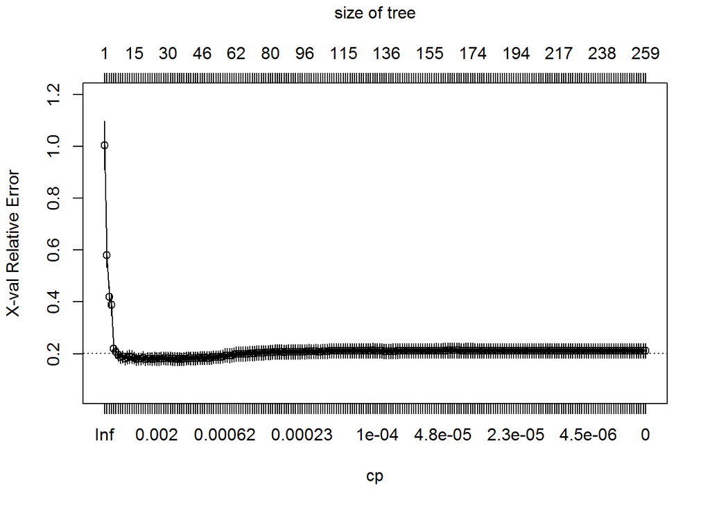

```r
## Validación cruzada: cp = 15
plotcp(modelo.arb.completo)
```

```r
error.completo <- modelo.arb.completo$cptable %>%
  data.frame() %>%
  dplyr::select(nsplit, CP, xerror)

error.completo %>% head(40)
```

```
##    nsplit          CP    xerror
## 1       0 0.464083251 1.0040573
## 2       1 0.169933244 0.5807498
## 3       2 0.062862723 0.4184382
## 4       4 0.062462785 0.3883358
## 5       5 0.017594792 0.2198174
## 6       6 0.014774575 0.2072229
## 7       7 0.013981502 0.1957263
## 8       8 0.008883102 0.1865550
## 9       9 0.008492174 0.1885686
## 10     10 0.005511344 0.1806158
## 11     11 0.005086823 0.1853079
## 12     12 0.005062905 0.1895190
## 13     13 0.004203229 0.1878031
## 14     14 0.003943028 0.1830125
```

[output cut: 26 more lines]

Error de prueba vs error de entrenamiento

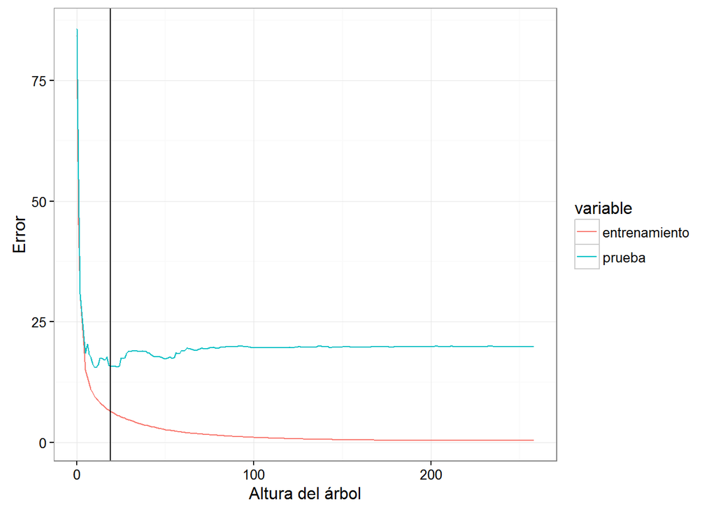

```r
alpha <- error.completo$CP

## Prueba vs entrenamiento
errores.vmc <- ldply(alpha,
                     function(i) {

                      modelo <- rpart(medv~., data = entrena.arb, method = "anova",
                                                             control=rpart.control(cp=i , xval=10, minbucket=1))

                      error.entrena <- mean((predict(modelo) - entrena.arb$medv)^2)

                      error.prueba <- mean((predict(modelo, prueba.arb)- prueba.arb$medv)^2)

                       data.frame(CP = as.numeric(i), prueba = error.prueba,
                                  entrenamiento = error.entrena)
                     })

errores.vmc %>%
  left_join(error.completo %>%
              dplyr::select(-xerror)) %>%
  gather(variable, valor, -CP, -nsplit) %>%
  ggplot(aes(x = nsplit, y = valor,
             colour = variable,
             group = variable)) +
  geom_line() +
  geom_vline(xintercept = 19) +
  xlab("Altura del árbol") +
  ylab("Error")
```

Árbol podado

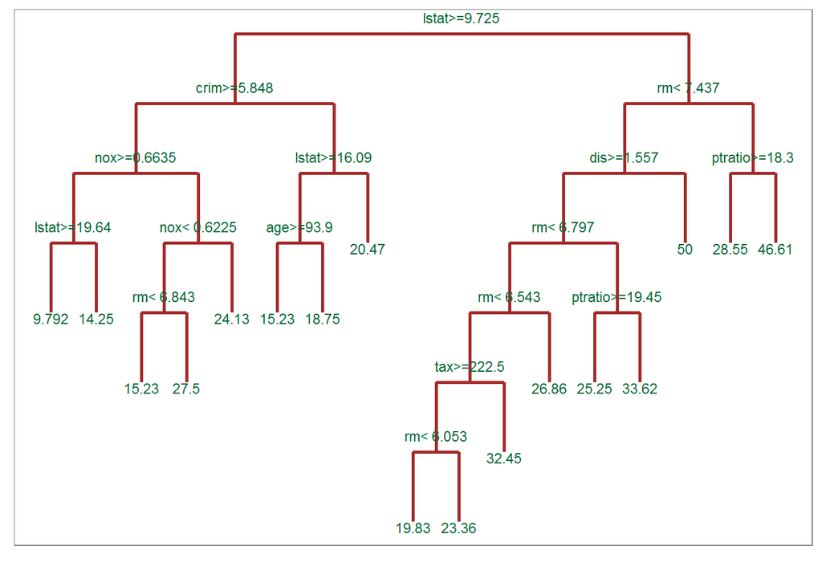

```r
## Modelo podado

modelo.arb.final <- rpart(medv~., data = entrena.arb, method = "anova",
                             control=rpart.control(cp=.0035 , xval=10, minbucket=1))

## Dendograma podado

ddata <- dendro_data(modelo.arb.final , uniform =T)

ggplot() +
  geom_segment(data = ddata$segments,
               aes(x = x, y = y, xend = xend, yend = yend), colour = "brown", size = 1) +
  geom_text(data = ddata$labels,
            aes(x = x, y = y, label = label), colour = "#006633", size = 3, vjust = -1) +
  geom_text(data = ddata$leaf_labels,
            aes(x = x, y = y, label = label), colour = "#006633", size = 3, vjust = 1) +
  theme_dendro()
```

```r
## error de prueba

mean((predict(modelo.arb.final, prueba.arb)- prueba.arb$medv)^2)
```

```
## [1] 17.08231
```

# Bagging y Bosques Aleatorios

Recordemos: $E_{rr}(x_0) = \sigma_\epsilon^2 + sesgo_\gamma^2(x_0) + Var_\gamma(x_0)$

## Bagging

Intuitivamente, **bagging** es considerar la *sabiduría de las masas*. En lugar de estimar de un sólo árbol, ponderamos la opinión de muchos.

Consideremos $L^1, L^2, ..., L^B$ muestras **independientes** e idénticamente distribuidas del mismo fenómeno $F(x)$. Si con cada una obtenemos un árbol $T_{L^i}$, definimos $T'(x) = \frac{1}{B} \sum_{i=1}^B T_{L^i}(x)$ como el *árbol bagging ideal* de manera que la predicción de $T'(x)$ es el promedio de los árboles $T_{L^i}(x)$. La pregunta es, ¿cómo se desempeña $T'$?

Por simplicidad, suponemos que el fenómeno tiene una respuesta cuantitativa.

Con respecto al sesgo podemos ver que $\begin{aligned} E[T'(x)] &= \frac{1}{B} \sum_{i=1}^B T_{L^i}(x) \\ &= \frac{1}{B} \sum_{i=1}^B T_{L}(x) = E[T_L(x)] \end{aligned}$ Por lo que el sesgo de $T'$ es idéntico al de un único árbol.

Sin embargo, la varianza cambia de la siguiente manera $Var(T'(x)) = \frac{1}{B} Var(T_L(x))$ a manera de que si $B$ es grande, el error cuadrático medio de $T'$ puede ser mucho menor que el de un árbol individual.

La parte relevante aquí es la palabra **independiente** de las muestras. Debido a que rara vez contamos con más de una muestra y difícilmente independientes entre sí, podemos utilizar muestras *bootstrap*.

Intuitivamente, si $F(x)$ es el mundo real y hacemos inferencia de él con una muestra $L$; *bootstrap* supone $L$ como el mundo real y hace inferencia de él con submuestras $L^{*i}$.

Sea $L = \{(x^i, y^i)_{i=1}^N\}$ una muestra de entrenamiento y sean $L^{*1}, L^{*2}, ..., L^{*B}$ muestras *bootstrap* de $L$. Es decir, cada $L^{*i}$ es una muestra con reemplazo de $(x^i, y^i) \in L$ con mismo tamaño de muestra $N$. Entonces el estimador *bagging por bootstrap* viene dado por: $\hat{T}^*(x) = \frac{1}{B} \sum_{i=1}^B T^{*i}(x)$ para variable de respuesta cuantitativa. En el caso cualitativo: $\hat{T}^*(x) = argmax_g \{\sum_{i=1}^B I(T^{*i}(x) = g)\}$

Por propiedades de *bootstrap* se puede ver que el sesgo de $T^*$ se mantiene. Para ver que pasa con el error cuadrático medio, se define $T^\dagger$ como el estimador *bootstrap* ideal que extrae muestras directamente de $F(x)$ tal que $T^\dagger(x) = E[T_L(x)]$. Entonces: $\begin{aligned} E[F(x) - T_L(x)]^2 &= E[F(x) - T^\dagger(x) + T^\dagger(x) - T_L(x)]^2 \\ &= E[F(x) - T^\dagger(x)]^2 + E[T_L(x) - T^\dagger(x)]^2 \\ &\geq E[F(x) - T^\dagger(x)]^2 \end{aligned}$ Por lo tanto, vemos que al predecir con *bagging* tomando muestras de la población, el error cuadrático medio queda exactamente igual o mejora. En la práctica no se puede muestrear de la población original, por lo que esto sólo sugiere que *bootstrap* puede ayudar, pero no hay garantía.

Ojo: Esta afirmación no se mantiene para la pérdida 0-1. En este caso, *bagging* de malos estimadores puede empeorar la predicción.

Por esto, se busca la manera de *decorrelacionar* las muestras para mejorar el error cuadrático. Esto da pie a la técnica que veremos a continuación.

## Bosques Aleatorios

Como vimos, *bagging* puede mejorar la predicción. Sin embargo, no está garantizado pues las muestras *bootstrap* están correlacionadas entre sí.

En la práctica generalmente se tiene una mejora.

La pregunta es, ¿cómo afecta esta correlación?

Supongamos que tenemos $T^*(x)$ un árbol ajustado con *bagging* obtenido de muestras *bootstrap* de $F(x)$. Entonces, si condicionamos a la muestra de entrenamiento $L$, vemos que: $Var(T^*(x)) = E[Var(T^*(x)|L)] + Var(E[T^*(x)|L])$ donde el primer término es la variación inducida por el remuestreo y el segundo es la varianza de cada submuestra.

Se puede ver que si $T(x) = \frac{1}{B} \sum_{i=1}^B T^{*i}(x)$ es un modelo basado en árboles obtenidos de una muestra *bootstrap*, entonces $\begin{aligned} Var(T(x)) &= \frac{1}{B} E[Var(T^*(x)|L)] + Var(E[T^*(x)|L]) \\ &= \frac{1}{B}E[Var(T^*(x)|L)] + Cov(T^{*i}(x), T^{*j}(x)) \end{aligned}$

Esto porque $\begin{aligned} Var(E[T^*(x)|L]) &= E_L[(E[T^*(x)|L])^2] - (E[T^*(x)])^2 \\ &= E_L[E[T^{*i}(x)|L]E[T^{*j}(x)|L]] - (E[T^*(x)])^2 \\ &= E_L[E[T^{*i}(x)T^{*j}(x)|L]] - (E_L[E[T^*(x)|L]])^2 \\ &= Cov(T^{*i}(x), T^{*j}(x)) \end{aligned}$

Por lo que el error cuadrático medio decrece siempre que logremos *decorrelacionar* la manera como se construyen los árboles que conforman $T(x)$.

Esto lo logramos con **bosques aleatorios** de la siguiente forma:

1. Para $b = 1, 2, ..., B$ y $m \leq p$ fija

   $p$ es el número de variables en la muestra $L$
   - Seleccionar muestra *bootstrap* $L_b^*$ de $L$
   - Construir un árbol $T_b^*$ basado en $L_b^*$. Pero en cada nodo, consideramos al azar $m$ variables de las $p$ disponibles como candidatas para cortes.
2. El predictor está dado por $T_{b.a.}(x) = \frac{i}{B} \sum_{b=1}^B T^{*b}(x)$ para regresión. Para clasificación por $T_{b.a.}(x) = argmax_g \{ \sum_{b=1}^B I(T^{*b}(x) = g) \}$

Por lo tanto, podemos pensar en **bosques aleatorios** como *bagging* con árboles *decorrelacionados*. Notemos que los parámetros para controlar la complejidad de los modelos vienen dados por $B$ el número de árboles y $m$ el número de variables candidatas a corte.

## Bosques Aleatorios en la práctica

A continuación algunas sugerencias de como buscar los valores de los parámetros de complejidad y algunas reglas de dedo.

Friedman, Hastie, and Tibshirani (2001)

**$B$: Número de árboles**

Se elige minimizando una estimación honesta del error. Esto implica hacer $B$ muy grande hasta que dicha estimación se estabilice.

**$m$: Número de variables candidatas para corte**

La regla de dedo del autor (y del paquete de R) sugiere:

- $m = \lfloor p / 3 \rfloor$ para regresión
- $m = \lfloor \sqrt{p} \rfloor$ para clasificación

**Tamaño de árboles**

## Estimación *Out-Of-Bag* (OOB) del error

El proceso de muestreo de los *bosques aleatorios* da una manera simple de construir una estimación honesta del error de predicción.

Sea $z_i = (x_i, y_i) \in L$. Definimos $T_{z_i} = \frac{1}{B_{z_i}} \sum_{z_i \notin L^{*j}} T^{*j}(x_i)$ donde $B_{z_i} = \sum_j I(z_i \notin L^{*j})$. Es decir, construimos el predictor promediando sólo aquellos árboles que **no** usaron $z_i$ en su construcción.

Por lo tanto, la estimación *OOB* del error de prueba para el bosque es: $\hat{Err_{oob}} = \frac{1}{N} \sum_{i=1}^N(y_i - T_{z_i})^2$

Es importante recalcar que si $B$ es grande, $\hat{Err_{oob}}$ es similar a la estimación por validación cruzada $N$. Sin necesidad de ajustar el modelo $N$ veces.

## Importancia de las variables

Otra bondad de los *bosques aleatorios* es que nos permiten calcular una medida de la importancia predictiva de las variables de entrada.

Para calcular dicha medida, consideremos un árbol $T^{*j}$. Usando la muestra *OOB* de $T^{*j}$, que es $L - L^{*j}$, estimamos su error *OOB*: $\hat{Err_{oob}} = \frac{1}{A_j} \sum_{z_i \in L - L^{*j}} (y_i - T^{*j}(x_i)^2)$ donde $z_i = (x_i, y_i)$ y $A_i = |L - L^{*j}|$ (el tamaño de muestra *OOB*).

Ahora, permutamos los valores de la variable $X_j$ en la muestra *OOB* para hacer algo similar a un análisis de sensibilidad y calculamos $\hat{Err_{oob}}(T^{*j})$ con la muestra *OOB* con la $k$-ésima variable permutada.

Finalmente, promediamos sobre el bosque $\hat{Imp}(k) = \frac{1}{B} \sum_{j=1}^B (\hat{Err_k(T^{*j})} -\hat{Err_{oob}}(T^{*j}))$ y denotamos esta medida como la *importancia relativa de la variable $x_j$*.

Podemos interpretar la importancia como el decremento en precisión que resulta de *quitar* la variable $x_j$.

Error Out-Of-Bag para selección de parámetros

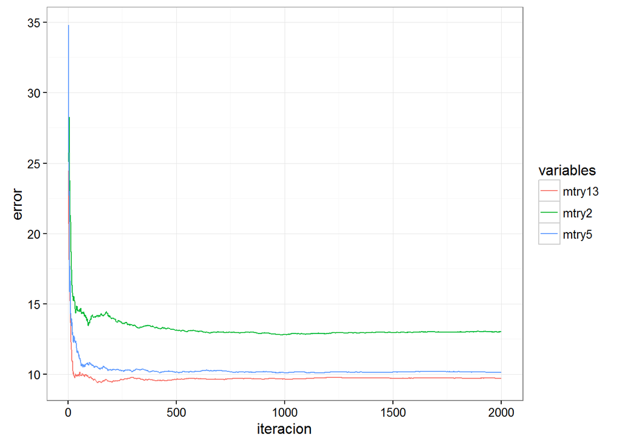

```r
## Método: RandomForest
## Datos: Boston Housing (librería mlbench)
## Librerías: randomForest

b <- 2000

## Probamos con distintos parámetros
bosque.2 <- entrena.arb %>%
  randomForest(medv ~ ., data = ., ntree = b, mtry = 2)
bosque.5 <- entrena.arb %>%
  randomForest(medv ~ ., data = ., ntree = b, mtry = 5)
bosque.13 <- entrena.arb %>%
  randomForest(medv ~ ., data = ., ntree = b, mtry = 13)

data.table(iteracion = 1:b,
    mtry2 = bosque.2$mse,
    mtry5 = bosque.5$mse,
    mtry13 = bosque.13$mse) %>%
  gather(variables, error, -iteracion) %>%
  ggplot(aes(x = iteracion, y = error, colour = variables,
      group = variables)) +
    geom_line()
```

```r
## Nos quedamos con los mejores parámetros
bosque <- entrena.arb %>%
  randomForest(medv ~ ., data = ., ntree = 1000, do.trace = 100, mtry = 13)
```

```
##      |      Out-of-bag   |
## Tree |      MSE  %Var(y) |
##  100 |    10.45    12.41 |
##  200 |     10.2    12.11 |
##  300 |    9.843    11.68 |
##  400 |    9.798    11.63 |
##  500 |     9.78    11.61 |
##  600 |    9.692    11.50 |
##  700 |    9.639    11.44 |
##  800 |    9.643    11.44 |
##  900 |    9.644    11.45 |
## 1000 |    9.705    11.52 |
```

Importancia de las Variables

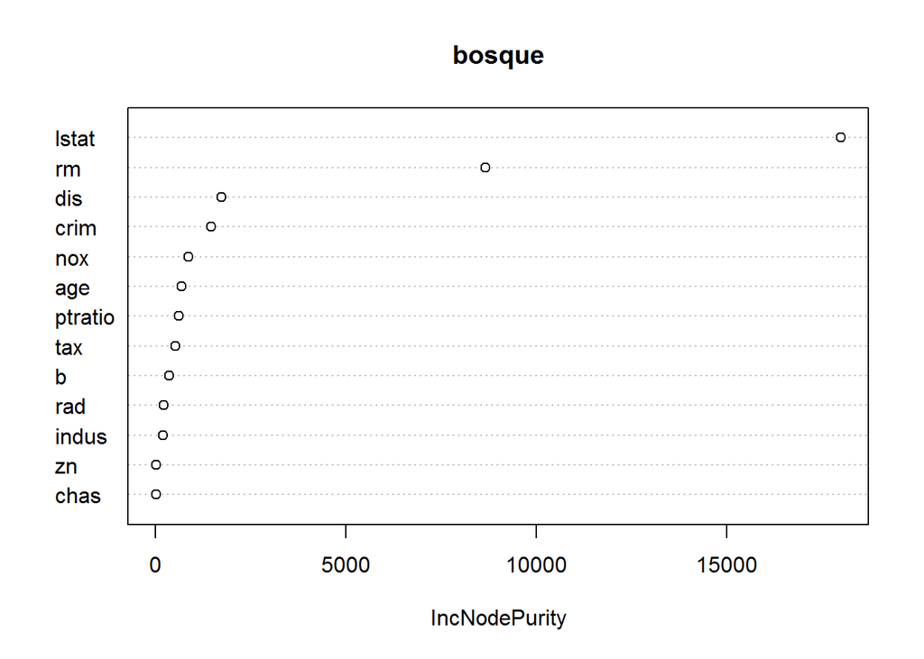

```r
varImpPlot(bosque)
```

```r
## Error cuadrático medio
## Recordemos que el de árboles de decisión era de ~ 17
mean((predict(bosque, prueba.arb) - prueba.arb$medv)^2)
```

```
## [1] 9.036051
```

## Adaboost

Este método también se basa en un ensamble de árboles como *bosques aleatorios* y *bagging*. La diferencia con estos otros métodos mencionados es que la sucesión de árboles se “adapta” a lo largo de las iteraciones.

Otro enfoque de ver a *Adaboost*, es que es un caso particular de la familia de modelos aditivos. Esta familia de modelos busca encontrar un conjunto ortogonal de funcionales en cada iteración. Aunque esto queda fuera del alcance de este curso, el lector interesado puede ver Friedman, Hastie, and Tibshirani (2001)

Supongamos que la variable de respuesta es $Y = \{-1, 1 \}$ y $X$ las variables de entrada. Construiremos una sucesión de $T_1, T_2, ..., T_M$ árboles para versiones **ponderadas** de la muestra de entrenamiento. El clasificador agregado será

$T_a(x) = signo \{ \sum_{m = 1}^M \alpha_m T_m (x) \}$

Los pesos $\alpha_m$ dependerán de la calidad de la predicción de $T_m (x)$.

Notemos que si los pesos $\alpha_m$ son iguales, tenemos un clasificador por mayoría de votos, pues

$\begin{aligned} T(x) &= signo \{ \alpha \sum_{m = 1}^M T_m (x) \} \\ &= signo\{ T_m (x) \} \end{aligned}$

### Algoritmo de Adaboost

1. Inicializamos los pesos $\omega_i = \frac{1}{N}$ con $i = 1, 2, ..., N$
2. Para $m = 1, 2, ..., M$:
1. Ajustar $T_m(x)$ a $L$ ponderado por $\omega_i$’s
2. Calcular tasa de error ponderada de $T_m(x)$ como $\hat{err_m} = \frac{\sum_{i=1}^N \omega_i^{(m)} I(y_i \neq T_m(x_i)) }{\sum_{i=1}^N \omega_i^{(m)}}$ y hacer $\alpha_m = log(\frac{1 - \hat{err_m}}{\hat{err_m}})$
3. Poner $\omega_i^{(m+1)} = \omega_i^{(m)} exp(\alpha_m I(y_i \neq T_m(x_i)))$
3. Clasificar con $T_a(x) = signo \{ \sum_{m = 1}^M \alpha_m T_m (x) \}$

### Algunas consideraciones

**Consideración 1:** ¿Cómo ajustar $T_m(x)$ con la muestra $L$ ponderada por $\omega_1, \omega_2, ..., \omega_N$?

Como vimos, para árboles tenemos distintos criterios de corte y decisión en nodos terminales. Por ejemplo, si queremos ajustar un árbol con la muestra ponderada y la **entropía** como medida de pureza, tenemos:

$i(t) = -\sum_{k=1}^K p_k(t)log(p_k(t))$ con $p_k(t) = \frac{\sum \omega_i I(g_i = k)}{\sum \omega_i}$

**Consideración 2:** ¿Cómo obtenemos dichos pesos $\omega_i$?

Supongamos $\omega_1^{(m)}, \omega_2^{(m)}, ..., \omega_N^{(m)}$ dados. Entonces, estimamos $\omega_i^{(m+1)} = \omega_i^{(m)} k_i^{(m)}$, donde

Recordemos que podemos inicializar $\omega_i^{(1)}$ con $\frac{1}{N}$ y tener un estimador por mayoría de votos

$k_i^{(m)} = \begin{cases} \frac{1-\hat{err_m}}{\hat{err_m}} & \quad \text{si } T_m(x) \neq y_i\\ 1 & \quad \text{si } T_m(x) = y_i \end{cases}$

Notemos que si $\hat{err_m} < 1/2$, entonces $\frac{1-\hat{err_m}}{\hat{err_m}} > 1$. Es decir, si el predictor se desempeña mejor que el azar pero se equivoca al predecir $(y_i, x_i)$, entonces *aumentamos* el peso de dicha observación en la siguiente iteración. Intuitivamente, estamos forzando a que el algoritmo *preste más atención* a observaciones mal clasificadas.

En el caso en que $\hat{err_m} > 1/2$, tenemos que $\alpha_m < 0$ y entonces *se voltea* la contribución de $T_m(x)$.

Recordemos que $\alpha_m = log(\frac{1-\hat{err_m}}{\hat{err_m}})$

**Consideración 3:** Es importante recalcar que si $\hat{err_m}$ se reduce, $\alpha_m$ se incrementa y viceversa. Por lo que en cada iteración, además de darle mayor importancia a los casos más difíciles de pronosticar, al predecir le damos mayor peso a los árboles que mejor clasifican.

```r
## Método: Adaboost
## Librerías: rpart

set.seed(3003)

## Tamaño de muestra (de entrenamiento)
N <- 250

## Conjunto de enternamiento
entrena <- rdply(N, rnorm(10))
## Modelo 2 * I(x ^ 2 > 9) - 1
entrena$y <- 2*(apply(entrena[,-1]^2, 1, sum) > 9)-1

## Conjunto de prueba
prueba <- rdply(1000, rnorm(10))
prueba$y <- 2*(apply(prueba[,-1]^2, 1, sum) > 9)-1

## Árbol de un sólo corte para comparar
arbol.1 <- rpart(y~., data = entrena, maxdepth = 1, method = "class")

## Error de árbol con un corte:
mean(predict(arbol.1, newdata = prueba, type="class")!=prueba$y)
```

```
## [1] 0.448
```

```r
## Árbol completo
arbol <- rpart(y~., data = entrena, method = "class", cp = 0)
printcp(arbol)
```

```
##
## Classification tree:
## rpart(formula = y ~ ., data = entrena, method = "class", cp = 0)
##
## Variables actually used in tree construction:
## [1] .n V1 V2 V3 V4 V6 V7 V9
##
## Root node error: 115/250 = 0.46
##
## n= 250
##
##         CP nsplit rel error  xerror     xstd
## 1 0.130435      0   1.00000 1.00000 0.068525
## 2 0.104348      2   0.73913 1.01739 0.068604
## 3 0.069565      3   0.63478 0.82609 0.066736
## 4 0.060870      4   0.56522 0.75652 0.065492
## 5 0.052174      5   0.50435 0.74783 0.065314
## 6 0.039130      6   0.45217 0.74783 0.065314
## 7 0.017391      9   0.32174 0.76522 0.065665
## 8 0.000000     12   0.26957 0.81739 0.066598
```

```r
## Árbol podado
arbol.pod <- prune(arbol, cp = 0.002)
## Error de árbol podado
mean(predict(arbol.pod, newdata = prueba, type = "class") != prueba$y)
```

```
## [1] 0.368
```

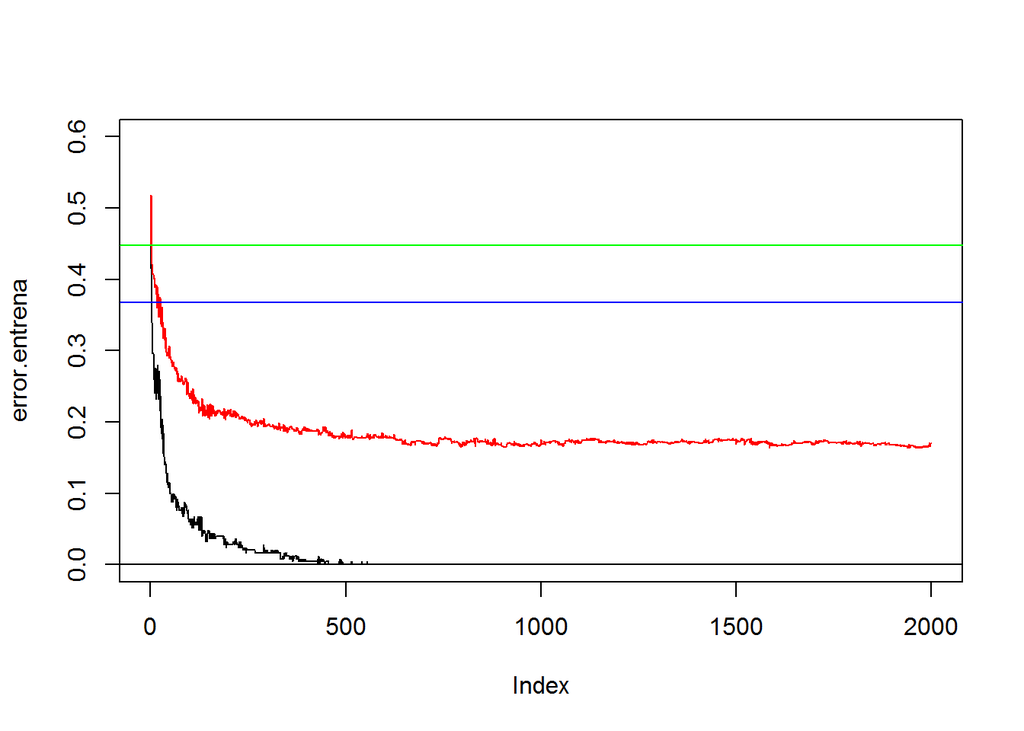

```r
## Ada Boost con árboles de 1 corte

arbol.lista <- list()
M <- 2000
alpha <- numeric(M)
error <- numeric(M)
error.prueba <- numeric(M)
error.entrena <- numeric(M)
w <- rep(1,nrow(entrena))
preds.boost <- numeric(N)
preds.boost.entrena <- numeric(N)

for(i in 1:M){
  #print(i)
  arbol.lista[[i]] <- rpart(y~., data = entrena,
      weights = w, maxdepth=1, method="class")
  preds <- predict(arbol.lista[[i]], newdata = entrena, type = "class")
  incorrectos <-  preds != entrena$y
  error[i] <- sum(incorrectos*w)/sum(w)
  alpha[i] <- log((1-error[i])/error[i])
  w <- w*exp(alpha[i]*(preds != entrena$y))
  # Función de predicción y evaluación
  preds.boost <- preds.boost + 0.5*alpha[i]*
      as.numeric(as.character(predict(arbol.lista[[i]],
          newdata = prueba, type="class")))
  preds.boost.entrena <- preds.boost.entrena + 0.5*alpha[i]*
              as.numeric(as.character(predict(arbol.lista[[i]],
                  newdata = entrena, type="class")))
  error.entrena[i] <- mean(sign(preds.boost.entrena) != entrena$y)
  error.prueba[i] <- mean(sign(preds.boost) != prueba$y)
}


## Graficamos error de entrenamiento
plot(error.entrena, type = "l", ylim = c(0, 0.6))
## Como referencia
abline(h = 0)
## Graficamos el error de prueba
lines(error.prueba, col = "red")
## Error con un árbol podado
abline(h = mean(predict(arbol.pod, newdata = prueba, type="class")!=prueba$y), col="blue")
## Error con un árbol
abline(h = mean(predict(arbol.1, newdata = prueba, type="class")!=prueba$y), col="green")
```

```r
## Error de Adaboost
mean(sign(preds.boost) != prueba$y)
```

```
## [1] 0.17
```

Breiman, Leo, Jerome Friedman, Charles J Stone, and Richard A Olshen. 1984. *Classification and Regression Trees*. CRC press.

Friedman, Jerome, Trevor Hastie, and Robert Tibshirani. 2001. *The Elements of Statistical Learning*. Vol. Second Edition. Springer series in statistics Springer, Berlin.

Gonzáles, Luis Felipe. 2013. *Aprendizaje Estadístico: Notas de Clase*. ITAM.